# TP de calcul formel

Durée : 3 h

Les données de cet énoncé devront être personnalisées à partir des valeurs de $x_0$ et $x_1$ indiquées dans le quiz.

Le texte qui suit est un notebook Jupyter unique qu'il vous est demandé de compléter avec de nouvelles instructions d'entrée à saisir pour obtenir les résultats demandés.

Vous indiquerez sans le quiz tous les résultats exacts ou tout au moins corrects à $10^{−4}$ près.

# Préliminaires

Charger toutes les fonctions de la librairie de calcul symbolique et exécuter la fonction permettant d'afficher les résultats à venir sous une forme mathématique.

# Questions

1- Déterminer la valeur minimum du réel $a$ pour laquelle le polynome suivant admet une racine double : $(240 a^{2} - (72 a^{2}+1430 a) x + (429 a - 24 a^{2}-60) x^{2}+(143 a+18) x^{3} + 6 x^{4})(x-x_1) $

2- On considère la matrice définie par $ m = \left( \begin{array}{cc} 1 & 2 & 3 & 4 \\ x_0 & x_0 & x_0 & x_0 \\ 1 & 1 & 1 & 1 \\ x_1 & x_1 & x_1 & x_1 \end{array} \right) $.

Pour vos valeurs de $x_0$ et $x_1$, indiquer la valeur de l'entier $k$ pour laquelle le coefficent en haut à droite de la matrice $m^k$ est le plus proche de 100.

3- Résoudre l'équation différentielle $y''+ 2 x_0*y' - x_0*y = t^2$ avec les conditions aux limites $y(0)=x_0$ et $y(1)=x_1$. Puis, indiquer la valeur de $t$ (à $10^{−4}$ près) pour laquelle la solution avec conditions aux limites précédente (notée $f$) prend la valeur $\frac{2x_0 + x_1}{3}$.

On pourra utiliser la fonction *bisect* de la librairie *scipy.optimize*, cette fonction permettant d'avoir la valeur approchée de la racine d'une fonction par dichotomie.

4- On considère la matrice $ m = \left( \begin{array}{cc} x_0 & 1 \\ 2 & x_1 \\ \end{array} \right) $.

Donner l'ordonnée du vecteur propre de $m$ d'abscisse $x_1$ et associé à la plus grande des valeurs propres de $m$.

5- Définir la rotation du plan $r$ de centre O et d'angle $\frac{10*\pi}{x_1}$ et appliquer la au nuage de points solutions de $(z^3-1)^2=2$.

Indiquer la plus petite abscisse des points du nuage obtenu après application de la rotation $r$.

6- Ecrire et éxécuter les instructions permettant de visualiser le signal en branches de paraboles de fréquence $x_0$ Hz et d'amplitude abs($x_0-x_1$) V (l'amplitude étant l'écart entre le minimum et le maximum du signal).

L'exemple ci-dessous correspond au cas d'une fréquence 50 Hz et d'une amplitude 70 V :

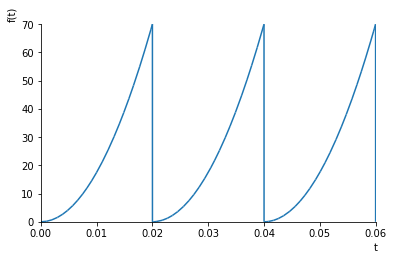

Calculer la valeur de l'harmonique de rang $n = 1$ en $\frac{1}{3x_0}$.